# Assignment 1 - Steve Cheney

2024-04-09

## Question 1

```r
my.sd <- function(input) {
  # sd = sqrt(sum(value(i) - mean) / count - 1)

  # Set up sums and counter variables
  count <- 0
  squares_sum <-0
  in_sum <- 0

  # Calc the sums for variance
  for(i in input){
    in_sum <- in_sum + i
    squares_sum <- squares_sum + i^2
    count <- count + 1
  }

  mean <- in_sum / count

  # Parts of the variance
  top <- (squares_sum - (count * mean^2))
  bottom <- count - 1

  # Calc standard deviation
  sd <- sqrt(top / bottom)

  return(sd)
}

vector <- c(10, 4, 65, 54, 12)
print(paste("My.sd:", my.sd(vector)))
```

```
## [1] "My.sd: 28.2665880502051"
```

```r
print(paste("R sd:", sd(vector)))
```

```
## [1] "R sd: 28.2665880502051"
```

```r
print(paste("My.sd == R sd:", my.sd(vector) == sd(vector)))
```

```
## [1] "My.sd == R sd: TRUE"
```

## Question 2

### Excerpt 1

```
x<-sin(1);print(x);y<-Sin(2);print(y)
x<-sin(1)
print(x)
y<-Sin(2)
print(y)
```

The above code’s intended functionality is to do the following:

1. Set the variable `x` to the sin of 1
2. Print `x`
3. Set the variable `y` to the sin of 2
4. Print `y`
5. And then repeat steps 1-4

But it runs with an error after printing `x` due to a syntax error:

```
[1] 0.841471
Error in Sin(2) : could not find function "Sin"
```

The functions `Sin` should be `sin` all lowercase in order to properly call the funciton.

### Excerpt 2

```
m <- matrix(c(1:5,NA,7,7,NA),
nrow=3,ncol=3,byrow=T)
print(m)

for ( i in 1:dim(m)[[1]] ) {
  mm <- sort(m[i,],na.last=c(NA,NA,T)[[i]])
  for ( j in 1:(length(mm)-1) ) {
    if ( mm[[j]]==mm[[j+1]] ) {
      cat(i,j,mm[[j]],fill=T)
    }
  }
}
```

The above code’s intended functionality is intended to do the following:

1. Create matrix `m` with:
   - Vector of sequence numbers from 1-5, `NA` (missing value), 7, 7, `NA`
   - With 3 rows
   - With 3 columns
   - And filling the matrix by row when `byrow` is set to `T` or `TRUE`
2. Print the matrix
3. Perform a for loop for each `i` in a sequence of numbers from 1 to the first element of the dimension vector of matrix `m`, or the number of rows in this case.
   - Create variable `mm` and set it to:
     - Sort the list elements of the matrix from the `i`th row to the end
     - Set the way NA values are handled: row 1 = remove `NA` values; row 2 = remove `NA`; row 3 place `NA` values at the end and choose the proper handled based on `i` (the current row)
   - Create a for loop for each `j` in a sequence of numbers from 1 to the length of `mm - 1`
     - Check and see if the current element within the row (so the sorted column value) is equal to the next value without checking out of bounds.
     - If `TRUE`:
       - Concatenate the row number, the column number, the sorted column value at that column number, and split the output into multiple lines to avoid spillover of the default `cat` width

But it runs with an error:

```
     [,1] [,2] [,3]
[1,]    1    2    3
[2,]    4    5   NA
[3,]    7    7   NA
3 1 7
Error in if (mm[[j]] == mm[[j + 1]]) { :
  missing value where TRUE/FALSE needed
```

This is happening because we are attempting to compare a `NA` or missing value with another value during some comparisons. When this happens, R returns `NA`, then trys to evaluate the if statement with `NA`, which results in an error since it should be a `TRUE` or `FALSE` value.

### Excerpt 3

```r
1:3 * 5:7
```

```
## [1]  5 12 21
```

```r
1:3 %*% 5:7
```

```
##      [,1]
## [1,]   38
```

```r
1:3 %*% t(5:7)
```

```
##      [,1] [,2] [,3]
## [1,]    5    6    7
## [2,]   10   12   14
## [3,]   15   18   21
```

The above code above does the following:

1. Performs multiplication of each item in the first vector with the corresponding item in the second vector
2. Performs matrix multiplication, however because the listed items are 1d vectors and not matricies, it ends up performing `1*5+2*6+3*7`
3. This performs a matrix multiplication of the first vector against the transposed column vector.

## Question 3

```r
if (!requireNamespace("BiocManager", quietly = TRUE))
    install.packages("BiocManager")

BiocManager::install("ALL")
library(Biobase)
data(aaMap)
ls()
```

```
## [1] "aaMap"  "my.sd"  "vector"
```

```r
save(aaMap, file = "aaMap.RData")
rm(aaMap)
ls()
```

```
## [1] "my.sd"  "vector"
```

```r
load("aaMap.RData")
ls()
```

```
## [1] "aaMap"  "my.sd"  "vector"
```

```r
write.table(aaMap, file = "aaMap.csv", sep = ",", row.names = FALSE)
```

Variables:

- name: Factor w/ 20 levels - amino acid name
- let.1: Factor w/ 20 levels - one-letter code
- let.3: Factor w/ 20 levels - three-letter code
- scProp: Factor w/ 2 levels - side chain property at pH 7 (polar/nonpolar)
- hyPhilic: logical - side chain is hydrophilic at pH 7
- acidic: logical - side chain is acidic at pH 7

```r
new_aaMap <- read.csv("aaMap2.csv") # Knitting overwrites the changed file every time, copied, edited, and saving into new var
summary(new_aaMap)
```

```
##      name              let.1              let.3              scProp
##  Length:20          Length:20          Length:20          Length:20
##  Class :character   Class :character   Class :character   Class :character
##  Mode  :character   Mode  :character   Mode  :character   Mode  :character
##
##
##
##   hyPhilic         acidic              pH
##  Mode :logical   Mode :logical   Min.   : 1.00
##  FALSE:6         FALSE:5         1st Qu.: 5.75
##  TRUE :7         TRUE :2         Median : 9.00
##  NA's :7         NA's :13        Mean   : 8.40
##                                  3rd Qu.:11.25
##                                  Max.   :14.00
```

## Question 4

### A

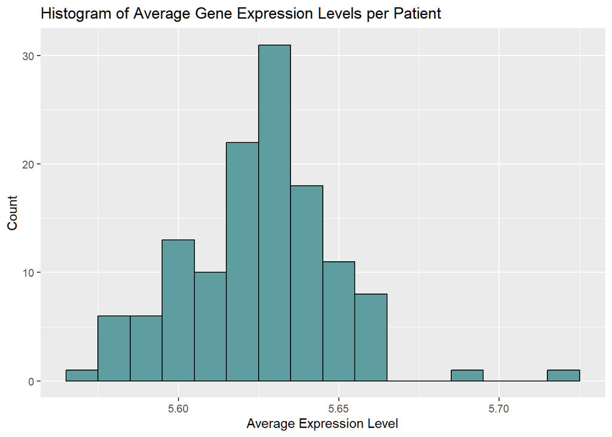

```r
library(ALL)
data(ALL)

expression <- exprs(ALL)

if (!require("ggplot2")) install.packages("ggplot2")
library(ggplot2)

avg <- colMeans(expression)

avg_df <- data.frame(PID = names(avg), AvgExp = avg)

# Histogram
ggplot(avg_df, aes(x = AvgExp)) +
  geom_histogram(binwidth = 0.01, fill = "cadetblue", color = "black") +
  ggtitle("Histogram of Average Gene Expression Levels per Patient") +
  xlab("Average Expression Level") +
  ylab("Count")
```

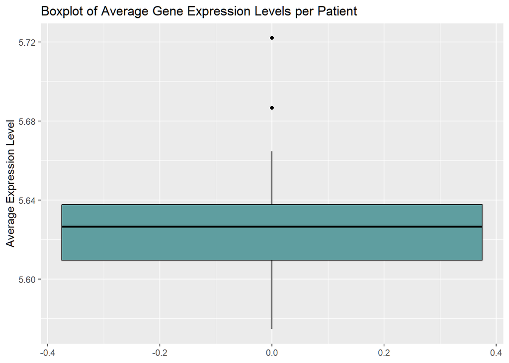

```r
# Boxplot
ggplot(avg_df, aes(y = AvgExp)) +
  geom_boxplot(fill = "cadetblue", color = "black") +
  ggtitle("Boxplot of Average Gene Expression Levels per Patient") +
  ylab("Average Expression Level")
```

```r
# Stem-and-leaf plot
stem(avg_df$AvgExp, scale = 2)
```

```
##
##   The decimal point is 2 digit(s) to the left of the |
##
##   557 |
##   557 | 56
##   558 | 0334
##   558 | 59
##   559 | 114
##   559 | 557899
##   560 | 00111223
##   560 | 5577779
##   561 | 0244
##   561 | 5566689
##   562 | 0000111122233
##   562 | 55555666778889999
```

[output cut: 19 more lines]

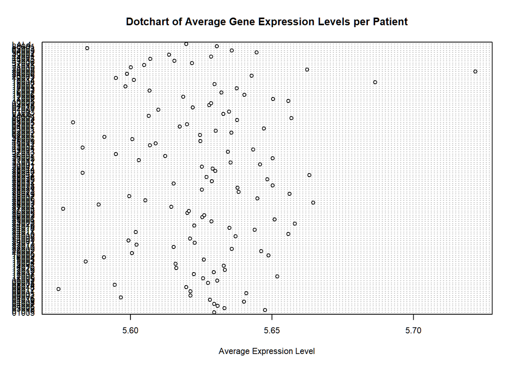

```r
# Dotchart
dotchart(avg_df$AvgExp, labels = row.names(avg_df), cex = 0.7,
         main = "Dotchart of Average Gene Expression Levels per Patient",
         xlab = "Average Expression Level")
```

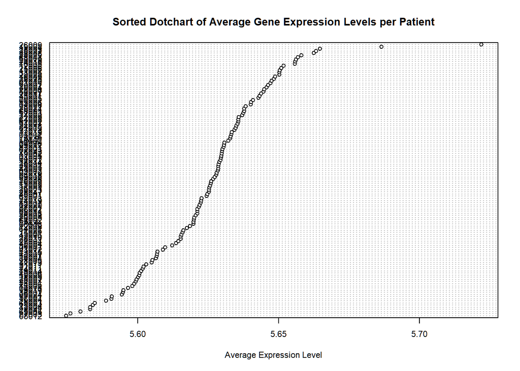

```r
# Ascending Order Vis
avg_df_sorted <- avg_df[order(avg_df$AvgExp),]
# Dotchart
dotchart(avg_df_sorted$AvgExp, labels = row.names(avg_df_sorted), cex = 0.7,
         main = "Sorted Dotchart of Average Gene Expression Levels per Patient",
         xlab = "Average Expression Level")
```

### B

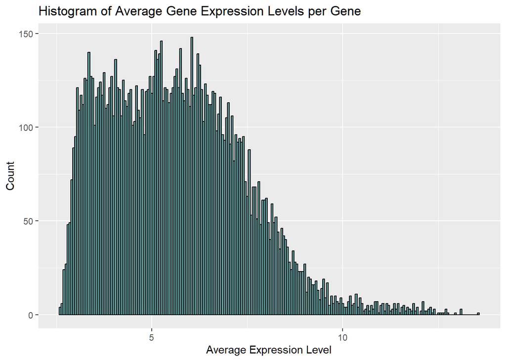

```r
library(ALL)
data(ALL)

gene_expression <- exprs(ALL)

if (!require("ggplot2")) install.packages("ggplot2")
library(ggplot2)

gene_avg <- rowMeans(gene_expression)
gene_avg_df <- data.frame(GID = rownames(gene_expression), AvgExp = gene_avg)

# Histogram
ggplot(gene_avg_df, aes(x = AvgExp)) +
  geom_histogram(binwidth = 0.05, fill = "cadetblue", color = "black") +
  ggtitle("Histogram of Average Gene Expression Levels per Gene") +
  xlab("Average Expression Level") +
  ylab("Count")
```

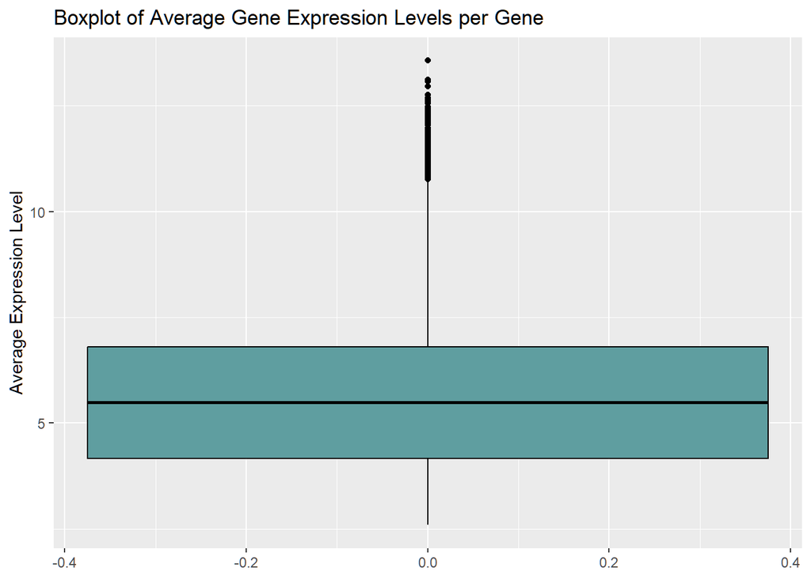

```r
# Boxplot
ggplot(gene_avg_df, aes(y = AvgExp)) +
  geom_boxplot(fill = "cadetblue", color = "black") +
  ggtitle("Boxplot of Average Gene Expression Levels per Gene") +
  ylab("Average Expression Level")
```

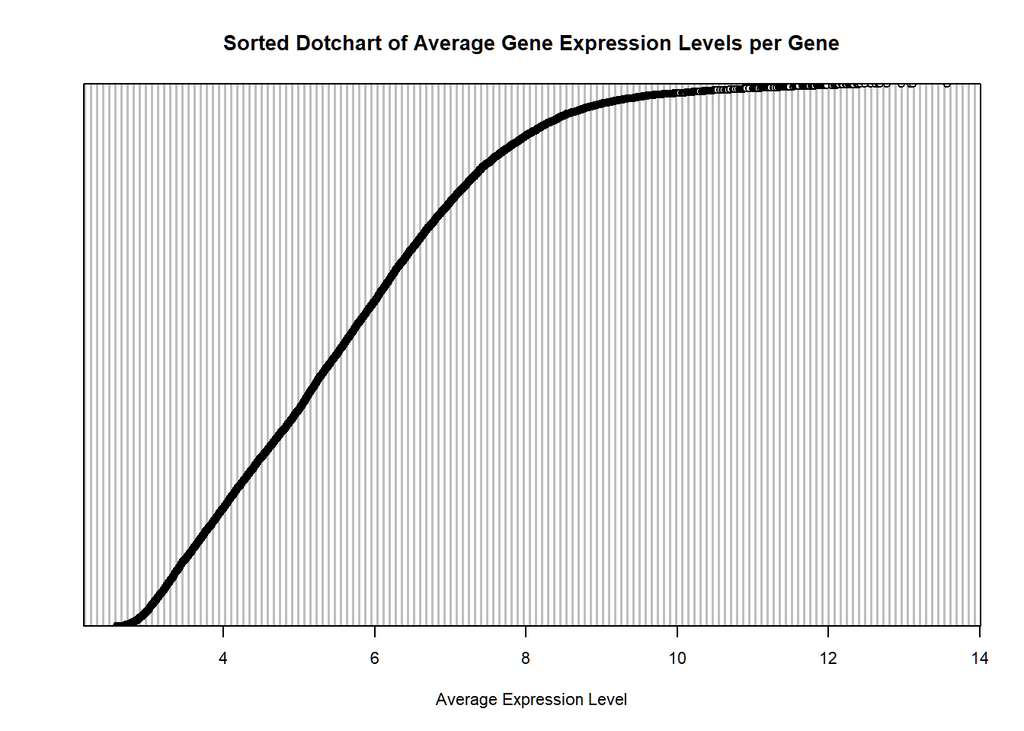

```r
# Ascending Order Vis
gene_avg_df_sorted <- gene_avg_df[order(gene_avg_df$AvgExp), ]

# Dotchart
dotchart(gene_avg_df_sorted$AvgExp, labels = gene_avg_df_sorted$GeneID, cex = 0.7,
         main = "Sorted Dotchart of Average Gene Expression Levels per Gene",
         xlab = "Average Expression Level")
```

### C

```r
library(ALL)
data(ALL)

expression <- exprs(ALL)

avg <- colMeans(expression)

mean(avg)
```

```
## [1] 5.624988
```

```r
median(avg)
```

```
## [1] 5.626497
```

```r
sd(avg)
```

```
## [1] 0.02262048
```

```r
mad(avg)
```

```
## [1] 0.01848821
```

```r
IQR(avg)
```

```
## [1] 0.02798012
```

```r
fivenum(avg)
```

```
##    08012    43012    26003    17003    26009
## 5.574651 5.609377 5.626497 5.637646 5.721977
```

```r
quantile(avg, probs = c(0, 0.25, 0.5, 0.75, 1))
```

```
##       0%      25%      50%      75%     100%
## 5.574651 5.609603 5.626497 5.637583 5.721977
```

```r
patient.means <- avg

library(ALL)
data(ALL)

expression <- exprs(ALL)

avg <- rowMeans(expression)

mean(avg)
```

```
## [1] 5.624988
```

```r
median(avg)
```

```
## [1] 5.49578
```

```r
sd(avg)
```

```
## [1] 1.789978
```

```r
mad(avg)
```

```
## [1] 1.955341
```

```r
IQR(avg)
```

```
## [1] 2.635843
```

```r
fivenum(avg)
```

```
##      31811_r_at        34032_at        35500_at          477_at AFFX-hum_alu_at
##        2.593761        4.166640        5.495780        6.802484       13.570571
```

```r
quantile(avg, probs = c(0, 0.25, 0.5, 0.75, 1))
```

```
##        0%       25%       50%       75%      100%
##  2.593761  4.166640  5.495780  6.802484 13.570571
```

1. Mean: 5.624988
2. Median: 5.49578
3. Standard deviation (sd): 1.789978
4. Median absolute deviation (mad): 1.955341
5. Interquartile range: 2.635843
6. Five number summary: 2.593761 4.166640 5.495780 6.802484 13.570571
7. Five number summary using quantile function: 2.593761 4.166640 5.495780 6.802484 13.570571
- The results here are notably different than our previous stats, most obviously because we are now grouping and averaging results based on a more closely related set of data with potentially less deviation. But, our standard deviation and IQR are larger because we are spreading our data points over individually more unique groups (genes) rather than a more closely related dataset (humans).

### E

As we have found in our previous work, `31811_r_at` has the lowest and `AFFX-hum_alu_at` has the highest average expression levels across all patients at 2.593761 and 13.570571 respectively.

```r
library(ALL)
data(ALL)

expression <- exprs(ALL)

smallest_i <- which(expression == min(expression), arr.ind = TRUE)
smallest_gene <- rownames(smallest_i)
all_smallest_gene <- expression[c(smallest_gene),]

greatest_i <- which(expression == max(expression), arr.ind = TRUE)
greatest_gene <- rownames(greatest_i)
all_greatest_gene <- expression[c(greatest_gene),]

df <- data.frame(
  all_smallest_gene,
  all_greatest_gene
)

print("Smallest Gene stats")
```

```
## [1] "Smallest Gene stats"
```

```r
smallest_gene
```

```
## [1] "34766_r_at"
```

```r
mean(df$all_smallest_gene)
```

```
## [1] 2.744006
```

```r
sd(df$all_smallest_gene)
```

```
## [1] 0.3156368
```

```r
mad(df$all_smallest_gene)
```

```
## [1] 0.2180966
```

```r
IQR(df$all_smallest_gene)
```

```
## [1] 0.2918073
```

```r
summary(fivenum(df$all_smallest_gene))
```

```
##    Min. 1st Qu.  Median    Mean 3rd Qu.    Max.
##   1.985   2.569   2.692   2.824   2.863   4.009
```

```r
quantile(df$all_smallest_gene)
```

```
##       0%      25%      50%      75%     100%
## 1.984919 2.568973 2.692133 2.860780 4.008608
```

```r
print("Greatest Gene stats")
```

```
## [1] "Greatest Gene stats"
```

```r
greatest_gene
```

```
## [1] "31687_f_at"
```

```r
mean(df$all_greatest_gene)
```

```
## [1] 12.39583
```

```r
sd(df$all_greatest_gene)
```

```
## [1] 1.589977
```

```r
mad(df$all_greatest_gene)
```

```
## [1] 1.208589
```

```r
IQR(df$all_greatest_gene)
```

```
## [1] 2.081935
```

```r
summary(fivenum(df$all_greatest_gene))
```

```
##    Min. 1st Qu.  Median    Mean 3rd Qu.    Max.
##   7.064  11.476  12.992  11.860  13.641  14.127
```

```r
quantile(df$all_greatest_gene)
```

```
##       0%      25%      50%      75%     100%
##  7.06356 11.55822 12.99171 13.64015 14.12657
```

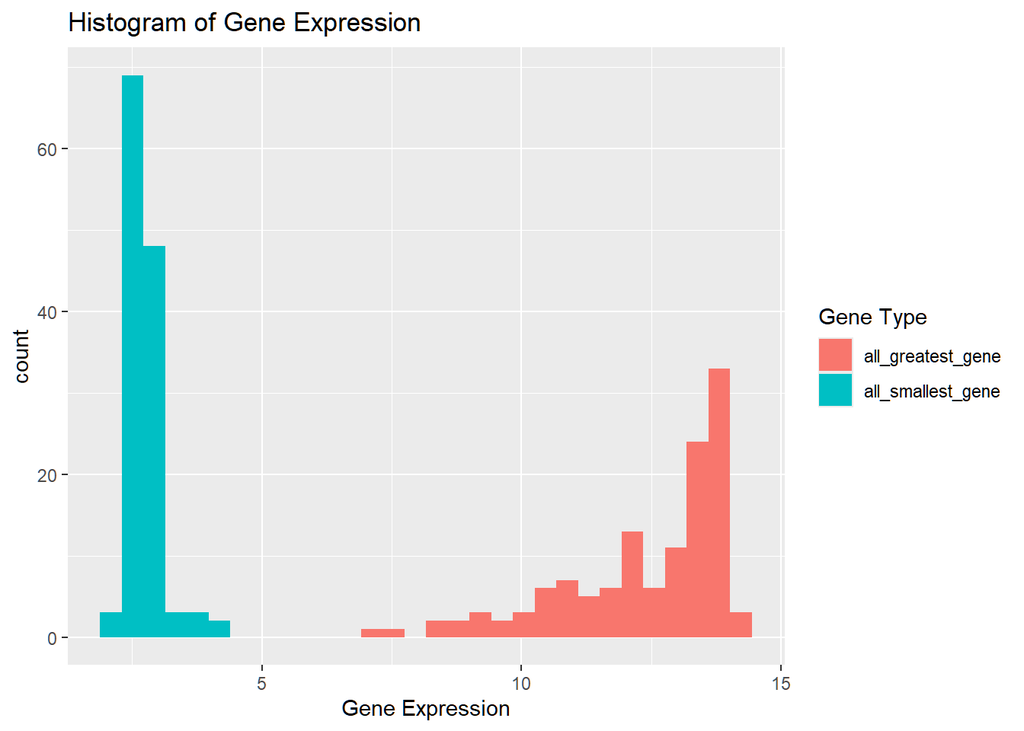

```r
df_col <- reshape(df,
                  varying = list(names(df)[grep("all_smallest_gene|all_greatest_gene", names(df))]),
                  v.names = "gene.exp",
                  timevar = "pt.exp",
                  times = names(df)[grep("all_smallest_gene|all_greatest_gene", names(df))],
                  new.row.names = 1:1e5,  # Increase if not enough row names
                  direction = "long")

df_min <- data.frame(smallest_gene = df[["all_smallest_gene"]])

df_max <- data.frame(greatest_gene = df[["all_greatest_gene"]])



library(ggplot2)
# Histogram
ggplot(data = df_col, aes(x = gene.exp, fill = pt.exp)) +
  geom_histogram(bins = 30) +
  labs(fill = "Gene Type", x = "Gene Expression", title = "Histogram of Gene Expression")
```

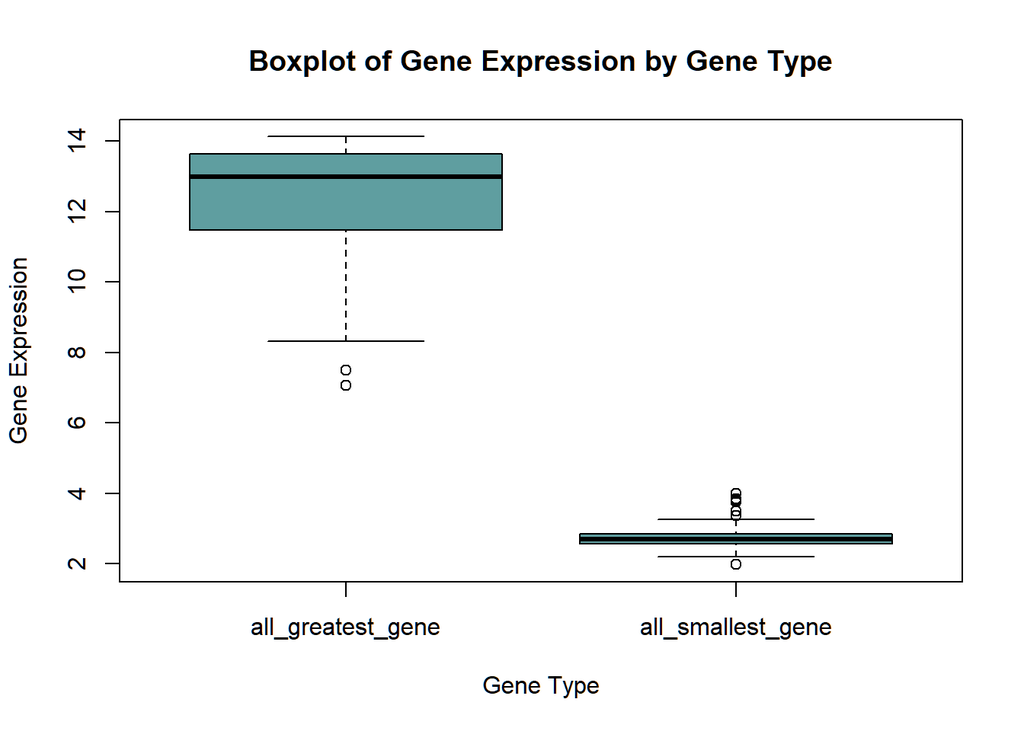

```r
# Boxplot
boxplot(gene.exp ~ pt.exp, data = df_col,
        xlab = "Gene Type", ylab = "Gene Expression",
        main = "Boxplot of Gene Expression by Gene Type",
        col = "cadetblue")
```

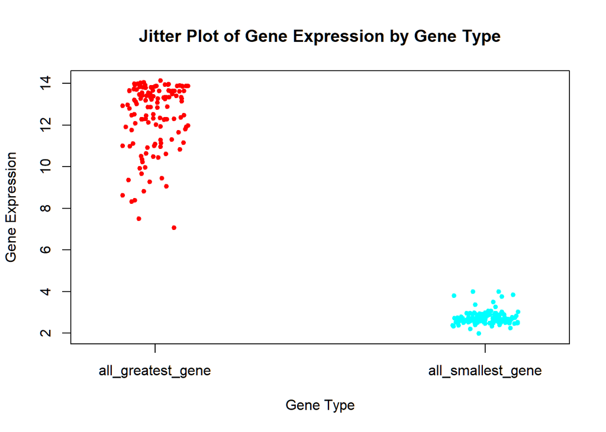

```r
# Jitter Plot
stripchart(gene.exp ~ pt.exp, data = df_col, vertical = TRUE,
           method = "jitter", jitter = 0.1, pch = 20, col = rainbow(length(unique(df_col$pt.exp))),
           main = "Jitter Plot of Gene Expression by Gene Type",
           xlab = "Gene Type", ylab = "Gene Expression")
```

```r
# Stem-and-Leaf Plot
stem(df_col$gene.exp, scale = 1.5, width = 50)
```

```
##
##   The decimal point is at the |
##
##    1 |
##    2 | 0223344444
##    2 | 55555555555555555566666666666666666666+50
##    3 | 000000001134
##    3 | 5888
##    4 | 00
##    4 |
##    5 |
##    5 |
##    6 |
##    6 |
##    7 | 1
##    7 | 5
##    8 | 34
##    8 | 68
##    9 | 1344
##    9 | 79
##   10 | 0244
##   10 | 556689
##   11 | 0000111233
##   11 | 688999
##   12 | 00113333333344
##   12 | 55555889999
##   13 | 00111222223333333344444
##   13 | 555556666666677777888889999999999999
##   14 | 000001
```

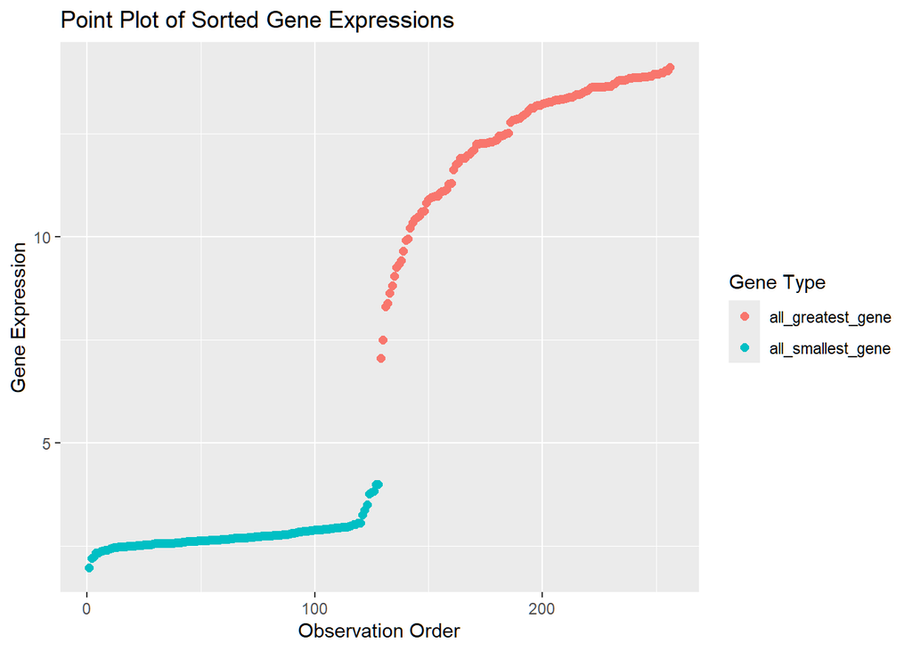

```r
# Sorting data frame
sorted_df <- df_col[order(df_col$gene.exp), ]
ggplot(data = sorted_df, aes(x = 1:nrow(sorted_df), y = gene.exp, color = pt.exp)) +
  geom_point(size = 2) +
  labs(x = "Observation Order", y = "Gene Expression", color = "Gene Type",
       title = "Point Plot of Sorted Gene Expressions")
```

### F

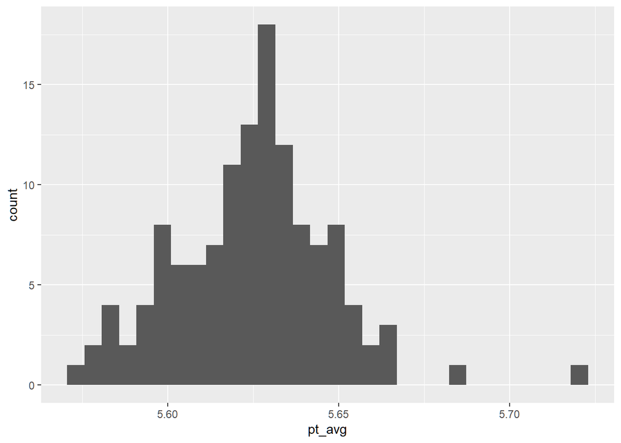

```r
pt_avg <- colMeans(expression)
pt_avg_df <- data.frame(PID = names(pt_avg), AvgExp = pt_avg)

gene_avg <- rowMeans(expression)
gene_avg_df <- data.frame(GID = rownames(gene_expression), AvgExp = gene_avg)

# Patient Plot
ggplot(
  data = pt_avg_df, aes(x = pt_avg)
) + geom_histogram(bins = 30)
```

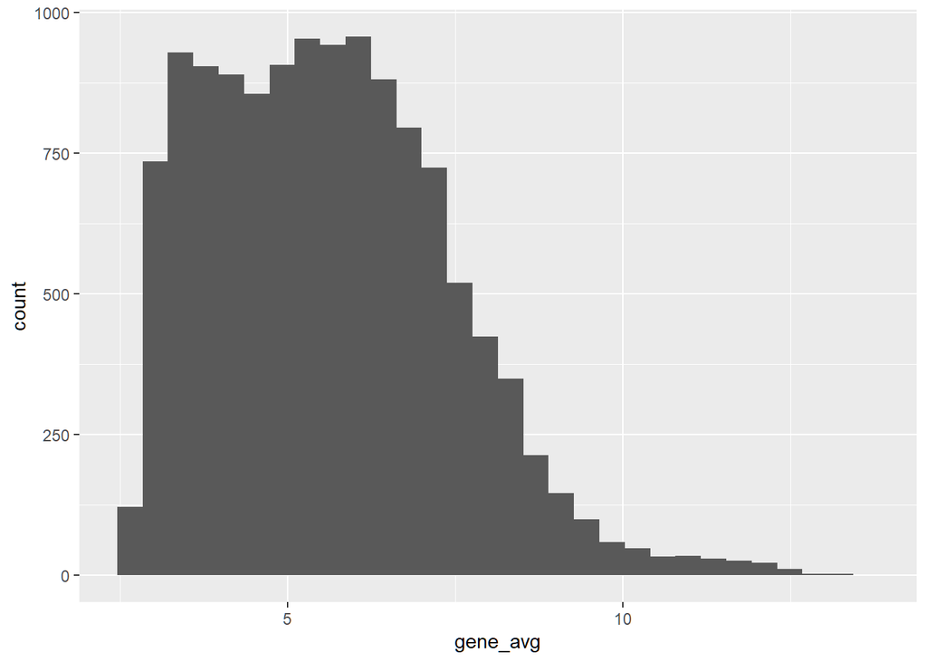

```r
# Gene Plot
ggplot(
  data = gene_avg_df, aes(x = gene_avg )
) + geom_histogram(bins = 30)
```

Let’s look at the above histograms to answer our comparison. Gene expression per gene has a broader spread than per patient, which is more narrowly distributed. This difference highlights the variability in gene expression across genes versus individual patients. This variability suggests that some genes are highly expressed while others show minimal activity, reflecting complex genetic regulation. On the other hand, the narrower spread among patients indicates a more uniform expression pattern, suggesting physiological consistency across individuals.